# Running SNAP Model

Stephen Wood

2022-10-31

## How to run the package

Once you have the package installed and loaded (following the steps on the README) you can use internal package data to see how the main functions work.

## Bootstrap approach

The first approach is to give the model a lower and upper estimate for each of the variables, along with the distribution type, in the model and use that to run the model based on a certain number of samples randomly drawn from those distributions.

To do this, we use the decisionSupport package to read in a data file that has the necessary information. Example data are saved within the package as a list.

```r
input_table
```

```
## $marginal
##                              distribution   lower median   upper
## carbon_discount_rate              posnorm    8.00     NA   13.00
## price_ton_carbon                  posnorm    8.00     NA   20.00
## mean_annual_rainfall              posnorm  450.00     NA  900.00
## grazing_intensity               tnorm_0_1    0.25     NA    0.90
## fire_frequency                      const    0.00     NA    0.00
## lignin_and_cellulose_content    tnorm_0_1    0.15     NA    0.35
## sand_percentage                   posnorm   25.00     NA   70.00
## sampling_depth                      const   30.00     NA   30.00
## soil_organic_cab_conc             posnorm    0.45     NA    0.54
## bulk_density                      posnorm    1.48     NA    1.54
## interventions_cost                posnorm 1000.00     NA 2500.00
##                                                                          Description
## carbon_discount_rate                                Carbon markets discount rate (%)
## price_ton_carbon                                         Price per ton of carbon ($)
## mean_annual_rainfall                                    Mean annual rainfall (mm/yr)
## grazing_intensity            Grazing intensity (1-(grazed biomass/ungrazed biomass))
## fire_frequency                                                Fire frequency (n/yrs)
## lignin_and_cellulose_content               Lignin and cellulose content (proportion)
## sand_percentage                                                  Sand percentage (%)
## sampling_depth                                                   Sampling depth (cm)
## soil_organic_cab_conc                   Soil organic carbon concentration (g C kg-1)
## bulk_density                                                   Bulk density (kg m-3)
## interventions_cost                                    Conservancy interventions cost
##
## $correlation_matrix
## NULL
##
## attr(,"class")
## [1] "estimate"
```

If you would like to read in your own data, you can create your own data based on the following format:

```r
input_table$marginal
```

```
##                              distribution   lower median   upper
## carbon_discount_rate              posnorm    8.00     NA   13.00
## price_ton_carbon                  posnorm    8.00     NA   20.00
## mean_annual_rainfall              posnorm  450.00     NA  900.00
## grazing_intensity               tnorm_0_1    0.25     NA    0.90
## fire_frequency                      const    0.00     NA    0.00
## lignin_and_cellulose_content    tnorm_0_1    0.15     NA    0.35
## sand_percentage                   posnorm   25.00     NA   70.00
## sampling_depth                      const   30.00     NA   30.00
## soil_organic_cab_conc             posnorm    0.45     NA    0.54
## bulk_density                      posnorm    1.48     NA    1.54
## interventions_cost                posnorm 1000.00     NA 2500.00
##                                                                          Description
## carbon_discount_rate                                Carbon markets discount rate (%)
## price_ton_carbon                                         Price per ton of carbon ($)
## mean_annual_rainfall                                    Mean annual rainfall (mm/yr)
## grazing_intensity            Grazing intensity (1-(grazed biomass/ungrazed biomass))
## fire_frequency                                                Fire frequency (n/yrs)
## lignin_and_cellulose_content               Lignin and cellulose content (proportion)
## sand_percentage                                                  Sand percentage (%)
## sampling_depth                                                   Sampling depth (cm)
## soil_organic_cab_conc                   Soil organic carbon concentration (g C kg-1)
## bulk_density                                                   Bulk density (kg m-3)
## interventions_cost                                    Conservancy interventions cost
```

The following variables can be excluded because they are not necessary to run the underlying SNAP model: carbon_discount_rate, price_ton_carbon, interventions_cost

If you have your own custom data, you can read it in with the following commands:

```r
# Set file location
input_table <- "data/Input_table.csv"

# Read in data file and save it
input_table <- decisionSupport::estimate_read_csv(input_table)
```

This should save the file in the proper list format needed by the decisionSupport package.

Now that you have data–whether using the package data or your own–you can run the model with the snap function. Assign the data with the input_table parameter. nsamp is the number of samples to draw from your specified distributions. The function will automatically print a variable importance plot for the variable that you choose. Your options are: change_carbon_stocks, equilibrium_soc, cashflow_carbon_stocks_NPV, carbon_project_NPV. For the last two variables to work you need to specify input values for the cost, price, and discount variables. In addition to printing a variable importance plot, the function returns the output of the simulations, which can be saved and used for other purposes.

Here is an example of the function where there is cost data and the response variable is project net present value:

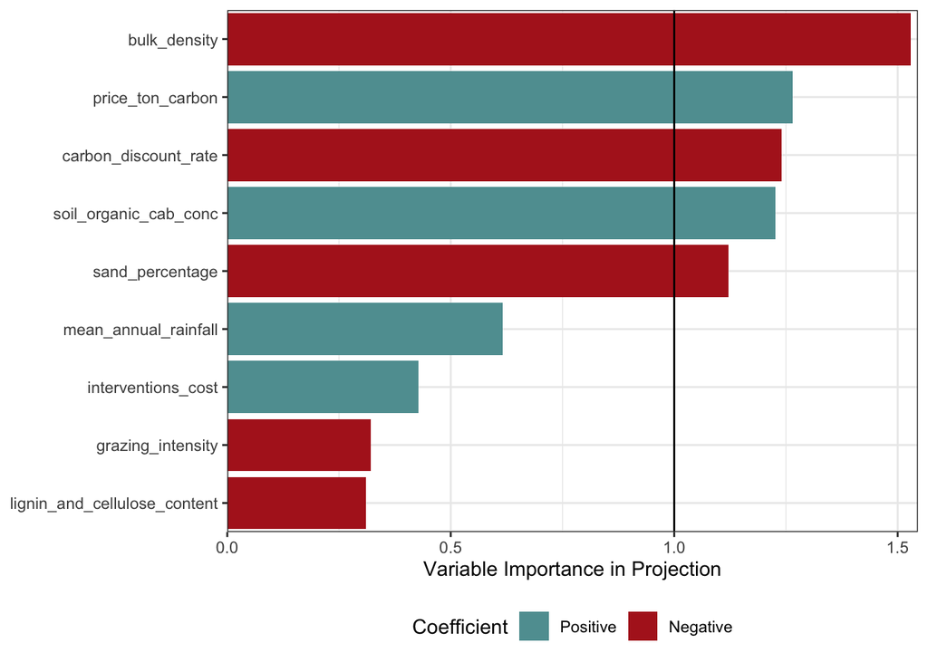

```r
cost <- snap(input_table = input_table,nsamp=1000,
     plot_vars=c('carbon_project_NPV'))
```

```r
head(cost$y)
```

```
##   change_carbon_stocks equilibrium_soc cashflow_carbon_stocks_NPV
## 1            -98.86542       -3323.995                 -3570.6775
## 2            169.18808        8549.356                  1111.7695
## 3            237.50975       11328.797                  4080.8880
## 4            229.55903        7112.896                  -157.4874
## 5            201.22272        7771.338                  2240.0092
## 6            469.75628       15547.610                  2778.6092
##   carbon_project_NPV
## 1         -3570.6775
## 2          1111.7695
## 3          4080.8880
## 4          -157.4874
## 5          2240.0092
## 6          2778.6092
```

Here is an example of the function where there is no cost data and the response variable is changes in carbon stocks:

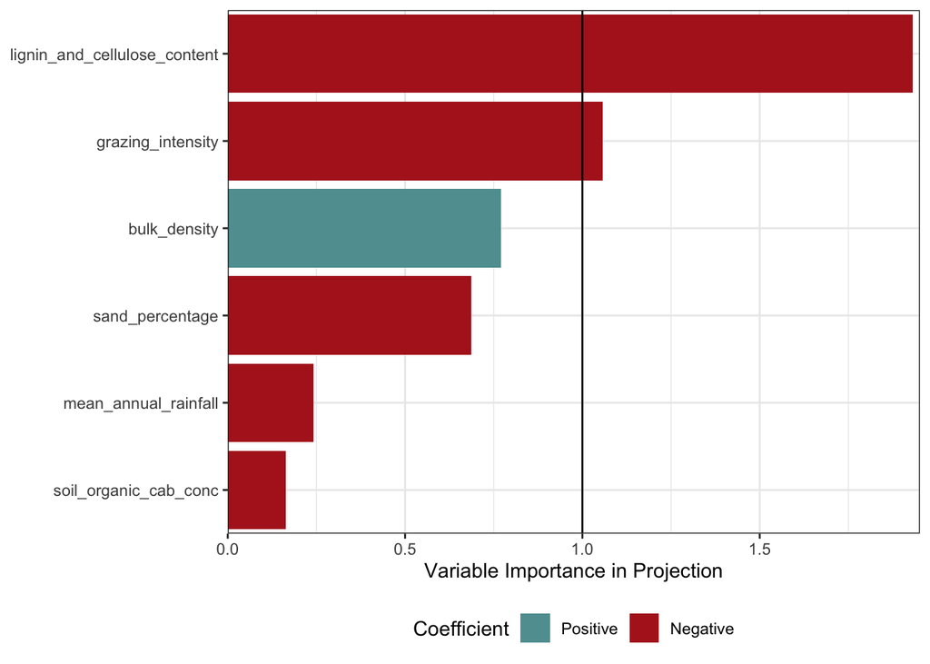

```r
nocost <- snap(input_table = input_noprice,nsamp=1000,
     plot_vars=c('change_carbon_stocks'))
```

```r
head(nocost$y)
```

```
##   change_carbon_stocks equilibrium_soc
## 1             206.3604        7402.332
## 2             189.8080        7770.512
## 3             183.4983        7878.952
## 4             763.2977       39264.088
## 5             116.5818        3785.434
## 6             247.7383       12588.496
```

## CALCULATION APPROACH

Still need to do

```r
# Read in fake data of 100 observations
#fake_data <- generate_data(read_csv("data/input_data.csv"))
```

```r
# Sample 100 new observations from the true data distributions
#data <- samp_data(fake_data,n=100)
```

```r
# Calculate SNAP outputs
#snap(data=data)
```